# Causal analysis in student theses: what has changed, and why

A memo for supervisors

Author

Affiliation

Ülo Maiväli

University of Tartu

Published

29 September 2026

## Kokkuvõte

**Miks teie üliõpilase töö äkki teistsugune välja näeb.** Epidemioloogias on kaua olnud tavaks küsida, milline tegur on haigusega „seotud“, kui teisi tegureid arvesse võtta, ja jätta põhjuslik tõlgendus arutelu ossa. Viimastel kümnenditel on põhjusliku järeldamise metoodika edasi arenenud ja sellest harjumusest loobunud. Nüüd sõnastatakse vaatlusliku uuringu küsimus nii, nagu kavandataks randomiseeritud katset. Seejärel püütakse vaatlusandmetega seda kujuteldavat katset (*target trial*) võimalikult täpselt jäljendada. Nii õpetavad ka kursuse õpik „The Bayesian Way to Causal Epidemiology“ ning Hernáni ja Robinsi raamat „Causal Inference: What If“. Seepärast näevad üliõpilaste analüüsid välja teisiti kui suurem osa senistest artiklitest.

**Mida käsikirjas tõenäoliselt märkate.**

- **Kõigepealt küsimus, siis andmed.** Töö algab põhjusliku küsimuse täpsest sõnastusest: milline sekkumine, kellele, kui pika aja jooksul ja millise tulemuse suhtes. Ilma selleta ei saa öelda, milliseid tegureid tuleks arvesse võtta.
- **Ühine stardijoon.** Jälgimine algab hetkest, mil patsient vastab valikukriteeriumidele ja ravi üle otsustatakse, nagu päris katses. Kui ravimi kasutajaks loetakse inimene, kes alustas ravi alles kaks aastat pärast jälgimise algust, kirjutatakse need kaks aastat, mil ta pidi sündmuseta elus püsima, ravimi arvele. Nii võib ka kasutu ravim paista kaitsvana.
- **Põhjusdiagramm p-väärtuste asemel.** Mudelisse lisatavad tegurid ei valita statistilise olulisuse järgi, vaid põhjusdiagrammi (DAG) abil, mis joonistatakse valdkonnateadmiste põhjal uuringuanmdetest sõltumatult. Diagrammi koostamisel on juhendaja valdkonnateadmine asendamatu.
- **Tabel 2 kaob.** Üks mudel vastab ühele küsimusele. Teiste tegurite kordajad selles mudelis ei ole nende tegurite mõjud, sest mudel on üles ehitatud uuritava ravi või ekspositsiooni jaoks. Seepärast ei ole töös tabelit, kus iga tegur on „sõltumatu riskitegur“ oma šansside suhtega.
- **Riskid šansside ja riskitiheduste suhete asemel.** Põhitulemus on, mitmel inimesel sajast tekiks haigus ühe või teise ravistrateegia korral, ning nende riskide vahe ja suhe. Šansside suhe (OR) paisutab mõju, kui haigus on sage, ja OR muutub isegi siis, kui mudelisse lisada tegur, mis üldse raviga seotud pole. Riskitiheduste suhe (*hazard ratio*) võrdleb igal ajahetkel ainult neid, kes on seni haigusest puutumata, mistõttu sekkumis- ja kontrollrühmade HR muutub aja jooksul eksitavalt isegi randomiseeritud katses. Kursusel asendatakse Coxi mudel Poissoni mudeliga, millest arvutatakse kumulatiivse haigestumise kõverad.
- **Paindlikud mudelid.** Mudel on siin vaid tööriist, millega ennustada iga inimese riski kummagi ravistrateegia korral. Seetõttu võivad selles olla ravi ja teiste tegurite koosmõjud ning kõverjoonelised seosed, ja lõpptulemus on ikkagi üks arv, mis on keskmistatud üle kogu uuritava populatsiooni.
- **Tõenäosusvahemikud „statistiliselt oluline või mitteoluline“ asemel.** Tulemus esitatakse hinnangu ja selle ebakindlust kirjeldava vahemikuna. Kursusel kasutatakse Bayesi meetodeid, mis lubavad öelda näiteks, kui tõenäoline on, et ravi riski vähendab. Põhjusliku analüüsi loogika sellest valikust ei sõltu.
- **Tundlikkusanalüüs.** Lause „mõõtmata tegurite mõju ei saa välistada“ asemel hinnatakse, kui tugev peaks mõõtmata segav tegur olema, et tulemust ümber pöörata.

**Kas see muudab tulemusi?** Memo lõpupoolel on simuleeritud näide, kus tõde on teada: ravim vähendab insuldiriski 40 protsendi võrra. Lihtne võrdlus ravitud ja ravimata patsientide vahel näitab vastupidist, justkui suurendaks ravim insuldiriski 67 protsendi võrra, sest ravi saavad raskemad haiged. Traditsiooniline mudel, kuhu tegurid valiti p-väärtuste järgi, annab šansside suhteks 0,37, kuigi tegelik šansside suhe on 0,58: see näitab ravimi kasu tunduvalt suuremana, sest sõela läbisid ka vahendaja ja ühine tagajärg. Põhjusdiagrammile tuginev analüüs annab riskide suhteks 0,60, tegelik riskide suhe on 0,60. Näide on teadlikult üles ehitatud nii, et need vead ilmneksid. See näitab, et traditsiooniline lähenemine võib eksida, mitte seda, kui sageli see päriselus juhtub.

**Mida uus lähenemine ei lahenda.** Ükski neist meetoditest ei kaitse mõõtmata segavate tegurite eest: põhjusdiagramm teeb eeldused nähtavaks, kuid ei muuda neid tõeks. Vaatlusuuringud, mis katset hoolikalt jäljendavad, jõuavad randomiseeritud katsetega sarnaste tulemusteni sagedamini kui need, mis seda ei tee, kuid ka nende kokkulangevus on mõõdukas, mitte täielik. Paljud artiklid, mis nimetavad end sihtkatse emulatsiooniks, ei järgi selle põhimõtteid. Ning mitte iga epidemioloogilise küsimuse taga ei ole kujuteldavat katset: sotsiaalmajandusliku seisundi või elukestva toitumise mõju puhul tuleb küsimus ümber sõnastada või otsida teist liiki tõendeid.

**Mida juhendaja saab küsida.** Milline oleks katse, mida analüüs jäljendab? Millal algab jälgimine? Kust pärineb põhjusdiagramm ja milliseid nooli saab vaidlustada? Kas esitatud arv vastab uurimisküsimusele? Kui tugev peaks olema mõõtmata segav tegur, et tulemust seletada?

Järgnev ingliskeelne memo selgitab iga muutust lähemalt ja viitab kirjandusele.

## Purpose

Students who learn causal inference from the course book, [*The Bayesian Way to Causal Epidemiology*](https://ymaivali.github.io/meth_book/), and from Hernán and Robins’s *Causal Inference: What If*,[^1] analyse observational data in ways that differ from the conventions of much of the published epidemiological literature. A supervisor reading a draft may find that the thesis has no table of mutually adjusted odds ratios, that the covariates were chosen from a causal diagram rather than by significance tests, that the main result is a difference in risks rather than a hazard ratio, and that the outcome model contains interaction terms whose coefficients are not reported.

This memo lists these changes, gives the reason for each, and cites the methodological literature behind it. The changes follow from the potential-outcomes framework and from causal diagrams, which were developed in epidemiology and statistics from the 1980s onward,[^2] and they are the content of current graduate teaching in causal inference, of guidance issued by journal editors,[^3] and of the TARGET reporting guideline for observational studies that emulate a target trial.[^4]

What the approach does not solve is listed in Section 11, and points on which methodologists disagree are listed in Section 12. A simulated example with a known answer is given in Section 10.

## Summary

Summary of the changes.

[output not shown]

## 1 The question is stated as a causal estimand

**Conventional practice.** The aim is to estimate “the association between X and Y, adjusted for potential confounders”. A causal interpretation, if any, appears in the discussion.

**What changes.** The student states the causal question as a comparison of outcomes under two or more well-defined interventions, in a specified population, over a specified period. For example: the 5-year risk of stroke if all eligible patients with hypertension started drug A at diagnosis, compared with the 5-year risk if none of them started it. This quantity is the *estimand*. The analysis is chosen to estimate it, and the conditions under which the estimate has a causal interpretation are listed: *exchangeability* (no unmeasured confounding given the adjustment set), *positivity* (patients of every covariate pattern could have received each treatment) and *consistency* (the treatment is defined precisely enough that a treated patient’s observed outcome is that patient’s outcome under the intervention).

**Why.** Whether a variable is a confounder is defined only relative to a causal question, so an “association adjusted for confounders” has no correct adjustment set until the question is stated. The same holds for the effect measure and the time horizon. Hernán has argued that stating the causal objective explicitly, instead of describing a causal estimate as an association, reduces ambiguity in the question, errors in the analysis and over-interpretation of the results.[^5] An exposure that does not correspond to a well-defined intervention, such as “obesity”, which can be changed by diet, exercise, surgery or illness with different consequences, does not define a single causal effect.[^6]

**What you will see.** A paragraph or table that defines the estimand; the word “effect” used in the results, together with the assumptions under which it applies. Further reading: Hernán and Robins, Chapters 1 and 3; the course book, [Chapter 11](https://ymaivali.github.io/meth_book/ch10-potential-outcomes.html#the-estimands-average-effects-and-their-scales).

## 2 The design is written as the protocol of a target trial

**Conventional practice.** Follow-up starts at cohort entry or at a calendar date. Exposure is defined as ever use, current use or cumulative use during follow-up. Patients who started treatment before the study period are analysed together with new users.

**What changes.** The student writes down the protocol of the randomised trial that would answer the question, the *target trial*: eligibility criteria, treatment strategies, assignment procedure, start and end of follow-up, outcome, causal contrast (intention-to-treat or per-protocol) and analysis plan. Each component is then emulated with the available data, and the compromises are listed.[^7] The central requirement is that eligibility, assignment to a treatment strategy and the start of follow-up coincide at a single *time zero*.

**Why.** When these three are not aligned, the design itself introduces biases that are separate from confounding.[^8]

- *Immortal-time bias.* If patients are classified as treated on the basis of treatment started after follow-up begins, the time before initiation, during which they had to remain event-free in order to start treatment, is counted as treated time.[^9]
- *Prevalent-user bias.* Patients who have been treated for some time are those who tolerated the treatment and survived its early period, and covariates measured at study entry may already have been affected by the treatment. A new-user design avoids both problems.[^10] Comparing initiators of the drug with initiators of an alternative treatment for the same indication (an active comparator) also reduces confounding by indication.

Reanalyses of well-known cohorts show that these design choices can change the conclusion. Observational studies had suggested a lower coronary risk in users of postmenopausal hormone therapy, whereas the Women’s Health Initiative trial found a higher risk. When the Nurses’ Health Study was reanalysed as a sequence of emulated trials of initiators versus non-initiators, the intention-to-treat hazard ratio for coronary heart disease was 1.42 (95% CI 0.92 to 2.20) in the first two years and 0.96 (0.78 to 1.18) over the whole follow-up, similar to the trial; the authors attributed the remaining difference between the two studies mainly to differences in time since menopause and in length of follow-up.[^11] In UK primary-care records, a comparison of current statin users with never users gave a hazard ratio for coronary heart disease of 1.31 (1.04 to 1.66), whereas an emulated trial of initiators versus non-initiators gave an intention-to-treat hazard ratio of 0.89 (0.73 to 1.09).[^12] For statins and cancer, analytic approaches used in earlier studies gave estimates that appeared strongly protective, whereas the emulated trial found a 10-year difference in cancer-free survival close to zero (−0.5 percentage points, 95% CI −1.0 to 0.0).[^13]

**What you will see.** A two-column protocol table (target trial and emulation); a diagram showing time zero; a smaller sample than a conventional analysis of the same database would use, because prevalent users and patients who were not eligible at time zero are excluded; and, when the strategies cannot be distinguished at time zero (for example “start treatment within 3 months”), copies (“clones”) of each patient assigned to every strategy and censored when their data stop being consistent with it. The TARGET guideline lists the items to report. Further reading: Hernán and Robins, Chapter 22 (Section 22.4 on time zero); the course book, [Chapter 14](https://ymaivali.github.io/meth_book/ch13-target-trial-emulation.html).

## 3 Confounders are chosen from a causal diagram

**Conventional practice.** Covariates are kept if their bivariable association with the outcome has a p-value below 0.05 (or 0.1, or 0.2), if they survive forward or backward stepwise selection, or if adding them changes the exposure coefficient by more than 10%.

**What changes.** Before analysing the outcome data, the student draws a directed acyclic graph (DAG) of the assumed causal relations among the exposure, the outcome and the other variables, based on subject-matter knowledge and the literature. The adjustment set is derived from the graph by the back-door criterion: it must block every non-causal path between exposure and outcome, and it must not contain variables affected by the exposure. Software such as `dagitty` lists the sufficient adjustment sets and the conditional independences that the graph implies and the data can test.[^14]

**Why.** Whether a variable should be adjusted for depends on its causal position, and its statistical association with the outcome does not reveal that position.

- A *mediator* (a variable on the path from exposure to outcome) and a *collider* (a common effect of exposure and outcome, or of their causes) are both associated with the outcome, often strongly, so a significance screen keeps them. Adjusting for a mediator removes part of the effect being estimated; adjusting for a collider creates an association between exposure and outcome that does not correspond to any effect.[^15]
- A variable that affects only the exposure (an *instrument*) adds variance when adjusted for and can amplify bias from residual confounding; in simulations the added error was usually small compared with the error from unmeasured confounding.[^16]
- A true confounder can fail a significance test in a small sample and be dropped.
- A change in the exposure coefficient after adding a covariate can reflect collider bias, or, for odds ratios and hazard ratios, non-collapsibility (Section 5), as well as confounding. Hernán and Robins (Section 7.4) note that definitions of confounding based on a change in the estimate were abandoned for these reasons.

When the full graph is not known, VanderWeele’s criterion requires only knowledge of whether each pre-exposure covariate is a cause of the exposure, of the outcome, or of both: adjust for every such cause, exclude known instruments, and include proxies for unmeasured common causes of exposure and outcome.[^21]

**What you will see.** A DAG figure, with the reasoning for the arrows included and omitted; a stated adjustment set; no table of bivariable screening results; possibly results under alternative graphs. A DAG is a statement of assumptions and deserves the same scrutiny as any other assumption. In a review of 234 applied articles that used DAGs, 48% reported the adjustment set and 21% the target estimand.[^22] Further reading: Hernán and Robins, Chapters 6 to 8 and 18; the course book, [Chapter 12](https://ymaivali.github.io/meth_book/ch11-dags.html).

**The supervisor’s contribution.** The DAG is only as good as the subject-matter knowledge that went into it, and this is the step of the analysis where a supervisor’s expertise is needed most: which factors drive prescribing, what happens between exposure and outcome, and which recorded variables are consequences of the outcome or of how patients came to be in the data.

## 4 Only the exposure effect is interpreted as an effect

**Conventional practice.** One multivariable model is fitted, and its table (often Table 2 of the paper) reports an adjusted odds ratio for every covariate, each described as an “independent risk factor”.

**What changes.** A model is built to estimate the effect of one exposure, and only that estimate is reported as an effect. If a study has several exposures of interest, each gets its own DAG-derived adjustment set and its own model. The coefficients of the other covariates are either omitted or shown in an appendix labelled as nuisance parameters.

**Why.** The adjustment set that identifies the effect of the exposure is generally not a valid adjustment set for any of the other covariates. For a confounder L of the exposure A, the model conditions on A, which lies on a causal path from L to the outcome, so the coefficient of L is at most a direct effect (the part not transmitted through A). The confounders of L may also be missing from the model, because they were not needed to adjust for A. Westreich and Greenland named the practice of reading all coefficients as effects the “Table 2 fallacy”.[^23] Section 10 shows an example.

**What you will see.** One effect estimate per causal question. Further reading: the course book, [Chapter 22](https://ymaivali.github.io/meth_book/ch21-multiple-regression.html#adding-predictors).

## 5 Effects are reported on the risk scale

**Conventional practice.** A binary outcome is analysed by logistic regression and summarised by an adjusted odds ratio; a time-to-event outcome is analysed by Cox regression and summarised by an adjusted hazard ratio.

**What changes.** The student reports the risk of the outcome under each treatment strategy, standardised to the study population, together with the risk difference and the risk ratio at stated times; for time-to-event outcomes, standardised cumulative incidence curves. For a binary outcome a logistic or Poisson model may still be fitted, and the change is in what is computed from the model and reported. For a time-to-event outcome the Cox model is replaced, not supplemented (see the end of this section).

**Why.**

- *Odds ratios overstate risk ratios for common outcomes.* The odds ratio is close to the risk ratio only when the outcome is rare; otherwise it is further from 1.
- *The odds ratio is not collapsible.* Adding to a logistic model a covariate that predicts the outcome but is unrelated to the exposure moves the odds ratio away from 1, even in a randomised trial with no confounding. Adjusted odds ratios from models with different covariate sets therefore estimate different quantities, are not comparable across studies, and none of them is the population-average effect. The risk difference and the risk ratio do not have this property.[^24] The coefficient of a Cox model is not collapsible either.[^25]
- *The hazard ratio conditions on survival.* The hazard at a given time is computed among those still event-free at that time. If treatment affects who survives, the treated and untreated survivors differ in their susceptibility after the first events, even in a randomised trial. The period-specific hazard ratio then has a built-in selection bias, and the single hazard ratio averaged over follow-up depends on how long the follow-up was.[^26] (Hernán and Robins, Technical Point 8.1 and Chapter 17.) When hazards are not proportional, which Stensrud and Hernán argue is the usual situation, the Cox hazard ratio is a weighted average of time-varying hazard ratios, and its value also depends on the pattern of censoring; they recommend supplementing it with survival differences or restricted mean survival differences at times prespecified in the protocol.[^27] This course goes further and does not report a Cox hazard ratio.
- *Decisions require absolute risks.* The number of events prevented per 1000 treated patients, or its reciprocal, the number needed to treat, requires the risk difference, which no ratio provides.

The standardised risks are obtained by g-computation: fit an outcome model, predict each person’s risk with treatment set to each strategy, average the predictions over the study population, and contrast the averages.[^28]

For time-to-event outcomes the course replaces the Cox model with a Poisson model of events in person-time. Follow-up is split into intervals, the event counts are modelled with a log person-time offset (the piecewise-exponential model), and the baseline rate is a spline in follow-up time, with a separate spline for each treatment group when the effect may change over follow-up. Unlike the Cox model, which leaves the baseline hazard unestimated, this model estimates the baseline rate, so the fitted rates can be accumulated into the cumulative incidence under each strategy and standardised over the cohort. The risk difference and risk ratio at stated times are read from these curves. When hazards are proportional, the model’s rate ratio equals the Cox hazard ratio; it is the same quantity under another name and has the same selection problem, which is why the causal contrast is taken on the cumulative incidence. Rate curves over follow-up, where shown, describe when events occur and are not reported as the effect. Hernán describes the same procedure with a pooled logistic model in the article cited above.

Two practical notes. First, students of this course fit binary outcomes with a Poisson working model and a log link, which gives risk ratios. This is the Bayesian counterpart of the “modified Poisson” regression of Zou,[^29] and it is intended. Second, where the outcome is rare and follow-up is short, the odds ratio, the hazard ratio and the risk ratio are numerically close and non-collapsibility is small, so the numbers may change little; the reason for the change there is interpretation and comparability. In a case–control study the odds ratio is what the design estimates, and with incidence-density sampling it estimates the rate ratio. Further reading: Hernán and Robins, Chapters 13 and 17; the course book, [Chapter 25](https://ymaivali.github.io/meth_book/08-glm.html#the-odds-ratio-is-not-collapsible), [Chapter 26](https://ymaivali.github.io/meth_book/ch25-survival-rates.html) and [Chapter 29](https://ymaivali.github.io/meth_book/ch24-bayesian-g-computation.html).

## 6 Outcome models contain interactions; the effect is still one number

**Conventional practice.** The model contains main effects only; interaction terms are tested and removed if not significant; continuous confounders enter as straight lines or in categories.

**What changes.** The outcome model includes exposure-by-covariate interactions and flexible terms (splines) for continuous confounders. Because the effect is obtained by standardisation (Section 5), the result is still a single population-average risk difference or risk ratio, whatever the number of terms. The individual coefficients are not interpreted.

**Why.** In this approach the outcome model is a device for predicting each person’s risk under each strategy. A main-effects model assumes that the exposure effect is the same, on the scale of the link function, for every combination of covariate values. If that is false, the single exposure coefficient differs from the population-average effect; in a linear model it is a weighted average of the covariate-specific effects, with weights that depend on the variance of treatment within strata rather than on the composition of the population. A straight line for a continuous confounder whose relation with the outcome is curved leaves residual confounding. Removing a term because its p-value exceeds 0.05 treats absence of evidence as evidence of absence; in this course, interaction terms that the data estimate poorly are kept and shrunk towards zero by the prior.

Effect modification, when it is a question of interest, is reported on both the additive (risk difference) and the multiplicative (risk ratio) scales, because whether an interaction is present depends on the scale: if the risk ratio is constant across a subgroup variable that changes the baseline risk, the risk difference varies across it.[^30] A non-significant product term in a logistic or Poisson model says nothing about the additive scale, which is the scale that determines how many events a treatment prevents in each subgroup.[^31] Further reading: Hernán and Robins, Chapters 4 and 5; the course book, [Chapter 17](https://ymaivali.github.io/meth_book/ch16-interaction.html) and [Chapter 24](https://ymaivali.github.io/meth_book/ch21c-curves-and-interaction.html).

## 7 Time-varying treatments are analysed with g-methods

**Conventional practice.** Covariates measured during follow-up are entered as time-dependent covariates in a Cox model, or the analysis adjusts for their latest values.

**What changes.** When the question concerns sustained treatment strategies (for example, “continue treatment throughout follow-up” versus “never start”), or the per-protocol effect in an emulated trial, the student uses g-methods: inverse-probability weighting of marginal structural models, the parametric g-formula, or g-estimation.

**Why.** A covariate measured during follow-up can be a confounder of later treatment and at the same time be affected by earlier treatment. Blood pressure, for example, influences whether antihypertensive treatment is continued and is itself lowered by that treatment. Adjusting for such a covariate in a regression model blocks part of the effect of earlier treatment and can introduce collider bias; not adjusting for it leaves later treatment confounded. Conventional regression cannot do both; g-methods can.[^32] Per-protocol effects are estimated by censoring patients when they deviate from their assigned strategy and weighting the remaining patients to correct for the selection this creates.[^33]

**What you will see.** Distributions of weights and their diagnostics; per-protocol estimates next to intention-to-treat estimates. Further reading: Hernán and Robins, Chapters 19 to 21 (Chapter 20 explains why the conventional methods fail); the course book, [Chapter 15](https://ymaivali.github.io/meth_book/ch14-time-varying-confounding.html).

## 8 Uncertainty is reported as intervals, not significance

**Conventional practice.** Results are classified as significant or non-significant at p < 0.05, and a non-significant result is reported as “no association”.

**What changes.** Results are reported as effect estimates with intervals, and significance thresholds are not used to decide what is reported or concluded. In this course the estimation is Bayesian (the `brms` interface to Stan): the result is the posterior distribution of the causal contrast, summarised by its median and a 95% credible interval and, where useful, by probabilities such as the posterior probability that the risk difference is below zero.

**Why intervals rather than significance.** A p-value is not the probability that the null hypothesis is true, a p-value above 0.05 is not evidence of no effect, and two studies with p-values on either side of 0.05 need not disagree with each other.[^34] The case against dichotomising results at a significance threshold has been argued in *Nature* by Amrhein, Greenland and McShane,[^35] and the *New England Journal of Medicine* revised its guidelines for statistical reporting in 2019.[^36]

**Why Bayesian estimation in this course.** There are three reasons. (i) The causal contrast is a non-linear function of many model parameters averaged over the study population; with posterior draws its distribution is obtained directly, without the delta method or the bootstrap. (ii) Prior distributions stabilise estimates in sparse strata and for interaction terms, so that terms are shrunk rather than deleted.[^37] (iii) A credible interval is a probability statement about the effect, given the model, the prior and the data, which is the interpretation readers usually give to a confidence interval. With large samples and weakly informative priors, the numbers are usually close to frequentist estimates and confidence intervals. The causal content of the previous sections does not depend on this choice: Hernán and Robins present the same causal methods with frequentist estimation. Further reading: the course book, [Chapter 29](https://ymaivali.github.io/meth_book/ch24-bayesian-g-computation.html) and [Appendix G](https://ymaivali.github.io/meth_book/16-appendix-H0.html).

## 9 Assumptions are stated and probed

**What changes.** The three assumptions of Section 1 are discussed one by one, and the analysis includes checks: covariate balance and the overlap of propensity scores between treatment groups, for positivity;[^38] negative-control outcomes or exposures, which should show no effect if confounding has been controlled; and a statement of how strong an unmeasured confounder would have to be to explain the result, such as the E-value, or a fuller quantitative bias analysis.[^39]

**Why.** The adjustment set is sufficient only if the DAG is correct and complete, and the data cannot establish that. A sensitivity analysis replaces the statement “residual confounding cannot be excluded” with the size of confounding that would change the conclusion, which a reader with subject-matter knowledge can then judge. Further reading: the course book, [Chapter 20](https://ymaivali.github.io/meth_book/ch19-sensitivity-analysis.html).

## 10 An illustration on simulated data

The course book uses one simulated cohort throughout: 50 000 patients with hypertension, and the question whether a blood-pressure-lowering drug prevents stroke. Patients with more severe disease are more likely both to receive the drug and to have a stroke (confounding by indication). Systolic blood pressure after the start of treatment (`sbp`) is a mediator, hospitalisation is a common effect of the drug and of stroke, and prescriber preference (`pref`) affects the drug but has no other effect on stroke. The structure is shown in Figure 1. Because the data are simulated, the true effect of the drug is known.

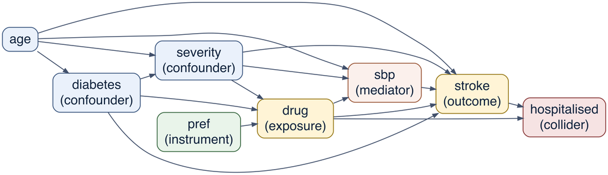

Figure 1: Causal diagram of the simulated cohort. The drug is the exposure and stroke the outcome; severity and diabetes are confounders; age affects the drug only through them and affects stroke directly; sbp (systolic blood pressure after treatment) is a mediator; hospitalised is a common effect of drug and stroke (a collider); pref (prescriber preference) affects only the drug.

**Show the R code**

```r
d     <- simulate_cohort(n = N_COHORT, seed = 2024)
truth <- cohort_truth(d)

# Crude comparison
crude <- avg_comparisons(glm(stroke ~ drug, family = poisson, data = d),
                         variables = "drug", comparison = "lnratioavg",
                         transform = "exp")

# Conventional analysis: keep every candidate whose bivariable association with
# stroke has p < 0.05, fit one logistic model, report the drug odds ratio
candidates <- c("age", "diabetes", "severity", "pref", "sbp", "hospitalised")
p_bivar <- sapply(candidates, function(v)
  summary(glm(reformulate(v, "stroke"), family = binomial, data = d))$coef[2, 4])
selected <- candidates[p_bivar < 0.05]
conv     <- glm(reformulate(c("drug", selected), "stroke"), family = binomial, data = d)
conv_or  <- exp(c(coef(conv)["drug"], confint.default(conv)["drug", ]))
conv_all <- exp(coef(conv))

# Backward stepwise elimination by AIC, for comparison
conv_step <- step(conv, direction = "backward", trace = 0)
dropped   <- setdiff(selected, attr(terms(conv_step), "term.labels"))

# DAG-based adjustment set {age, diabetes, severity}
# (a) conditional odds ratio from a main-effects logistic model
dag_logit <- glm(stroke ~ drug + age + diabetes + severity, family = binomial, data = d)
dag_or    <- exp(c(coef(dag_logit)["drug"], confint.default(dag_logit)["drug", ]))

# the DAG-based logistic model plus the mediator only, or plus the collider only
or_plus <- function(v) exp(coef(glm(reformulate(c("drug", "age", "diabetes",
  "severity", v), "stroke"), family = binomial, data = d))["drug"])
or_sbp  <- or_plus("sbp")
or_hosp <- or_plus("hospitalised")

# (b) outcome model with drug-covariate interactions and a spline for age,
#     standardised over the cohort (g-computation) with marginaleffects
dag_pois <- glm(stroke ~ drug * (splines::ns(age, 3) + diabetes + severity),
                family = poisson, data = d)
g_rd <- avg_comparisons(dag_pois, variables = "drug")
g_rr <- avg_comparisons(dag_pois, variables = "drug",
                        comparison = "lnratioavg", transform = "exp")
```

Table 1: Estimates of the effect of the drug on stroke from the same simulated data. The models are fitted with `glm()` so that the comparison concerns the choice of covariates and of the reported quantity only; the course book repeats the standardised analysis with `brms` and obtains a posterior distribution.

| Analysis | Covariates adjusted for | Measure | Estimate (95% CI) |
| --- | --- | --- | --- |
| Crude comparison | none | risk ratio | 1.67 (1.54 to 1.82) |
| Conventional: covariates kept if bivariable p < 0.05; logistic regression | age, diabetes, severity, pref, sbp, hospitalised | odds ratio | 0.37 (0.32 to 0.42) |
| Logistic regression with the DAG-based adjustment set | age, diabetes, severity | odds ratio | 0.58 (0.52 to 0.64) |
| DAG-based set; drug × covariate interactions, spline for age; standardised over the cohort | age, diabetes, severity | risk ratio | 0.60 (0.54 to 0.67) |
| as above | as above | risk difference, percentage points | -2.75 (-3.49 to -2.02) |
| **True effect**, from the simulated potential outcomes |  | risk ratio; odds ratio; risk difference, percentage points | 0.60; 0.58; -2.72 |

In Table 1, bivariable screening at p < 0.05 kept all six candidate covariates; the largest p-value, for `pref`, was 0.0014. Two of the six must not be adjusted for: `sbp` is a mediator and `hospitalised` is a collider. A third, `pref`, affects stroke only through the drug, so adjusting for it costs precision without removing bias. The resulting odds ratio, 0.37, is far from the true effect, and its confidence interval excludes the true value: with 50 000 patients the interval is narrow, but it is centred on a biased estimate. Adding the mediator alone to the DAG-based logistic model moves its odds ratio from 0.58 to 0.70, and adding the collider alone moves it to 0.31. Backward stepwise elimination by AIC removed only pref.

With the DAG-based adjustment set, both the conditional odds ratio and the standardised risk ratio are close to the truth. The outcome is uncommon (4.8% of patients had a stroke), so in this example the odds ratio and the risk ratio almost coincide and non-collapsibility is small; the error of the conventional analysis comes from the choice of covariates, not from the choice of effect measure. With a common outcome the two measures separate, as the course book shows in [Chapter 25](https://ymaivali.github.io/meth_book/08-glm.html#the-odds-ratio-is-not-collapsible).

The same conventional model, read as a Table 2, gives the following adjusted odds ratios for the covariates. None of them is the effect of that covariate on stroke.

Table 2: The covariate coefficients of the conventional model.

| Covariate | Adjusted odds ratio | What the coefficient is, given the diagram |
| --- | --- | --- |
| hospitalised | 12.0 | Hospitalisation is caused by stroke (and by the drug); the odds ratio reflects that, not an effect of hospitalisation on stroke. |
| diabetes | 1.94 | The model conditions on severity, the drug and `sbp`, all of which lie on paths from diabetes to stroke, so this is not the total effect of diabetes. |
| severity | 1.82 | The model conditions on the drug and `sbp`, which carry part of the effect of severity, so this is at most a direct effect. |
| age, per year | 1.017 | The model conditions on diabetes, severity and `sbp`, all of which are affected by age, so this is at most a direct effect. |

The simulation was constructed to contain these structures. It shows that the conventional procedure can fail, and why; it does not show how often it fails in real data.

## 11 What the approach does not solve

- **Unmeasured confounding.** A DAG makes the assumptions explicit; it does not make them true. Target trial emulation addresses biases introduced by the design, such as misalignment of eligibility, assignment and time zero, and not biases in the data, such as confounding and measurement error.[^40] An unmeasured confounder biases the estimate whatever the estimator, and a large sample then gives a narrow interval around the biased value.
- **A wrong or incomplete graph** gives a wrong adjustment set. A DAG also does not show effect modification or the functional form of the relations.
- **Model specification.** g-computation depends on a correctly specified outcome model, inverse-probability weighting on a correctly specified treatment model, and doubly robust estimators on at least one of the two.
- **The label is not a guarantee.** In a review of 200 studies that explicitly aimed to emulate a target trial, 57% did not describe the target trial protocol and its emulation.[^41] In a cross-sectional study of 237 such studies published in high-impact clinical journals, 56.5% had a prespecified protocol, 15.2% used information from after baseline to define eligibility, 16.9% showed a diagram defining time zero, and 30.8% addressed unmeasured confounding.[^42]
- **Agreement with trials is moderate and depends on how closely the trial can be emulated.** In the RCT-DUPLICATE project, which emulated 32 trials selected for feasibility in claims data, the correlation between emulated and trial estimates was 0.82 (95% CI 0.64 to 0.91) overall, 0.93 in the 16 closely emulated trials, and 0.53 in the other 16.[^43] A systematic review of 106 emulation–trial pairs found a correlation of 0.58 (0.43 to 0.69), and 0.83 (0.73 to 0.89) in the 62 pairs that emulated the trial design more closely.[^44] The two sources are not independent: 29 of the review’s 106 pairs are RCT-DUPLICATE emulations, and its definition of close emulation is adapted from RCT-DUPLICATE. Excluding those 29 pairs left the pooled ratio of emulation to trial estimates unchanged, at 0.97 (0.91 to 1.04).
- **Scope.** The framework applies to exposures that correspond to well-defined interventions. For exposures such as socioeconomic position, ethnicity or lifetime diet there is no trial to emulate, even in principle, and the question has to be reformulated or answered by other means (course book, [Chapter 14](https://ymaivali.github.io/meth_book/ch13-target-trial-emulation.html#the-limits-of-the-target-trial-framing)).

## 12 Where methodologists disagree

The recommendations above are those of the causal-inference literature cited in this memo. They are not held by all statisticians and epidemiologists, and a student’s thesis should be judged on whether the choices are justified, not on whether they follow this memo.

- **Odds ratios.** Doi and colleagues argue, from mathematical derivation and 140 620 trials in the Cochrane database, that the risk ratio depends on the baseline prevalence of the outcome while the odds ratio does not, and they propose replacing the risk ratio with the odds ratio in trials and meta-analyses; their paper opened a “Controversy and Debate” series in the journal.[^45] The position of the course book is that, for a stated population, the standardised risk difference and risk ratio answer the causal question directly, and that transporting an effect to another population requires modelling the effect modifiers on any scale.
- **Hazard ratios.** Fay and Li conclude that the hazard ratio has no individual-level interpretation without strong untestable assumptions, but that under proportional hazards a population-level hazard ratio remains a useful causal estimand if it is interpreted with attention to the causal model.[^46] Hernán himself does not propose abandoning hazard ratios: in the article cited in Section 5 he writes that a series of average hazard ratios over increasing follow-up periods is informative. The course does not take either route: students replace the Cox model with the Poisson survival model described in the section on effect measures (Section 5) and report standardised cumulative incidence curves.
- **The scope of the interventionist framework.** Vandenbroucke, Broadbent and Pearce, and Krieger and Davey Smith, argue that making the potential-outcomes approach the standard for all of epidemiology would restrict the questions asked, the designs used and the evidence accepted, and they propose a pluralistic approach to causal inference.[^47] Supervisors in social, life-course or nutritional epidemiology should expect a student to discuss how this applies to their exposure.
- **Data-driven covariate selection.** The objection in Section 3 is to selecting covariates by their association with the outcome without regard to their causal position. Where there are hundreds of candidate covariates, as in health-care claims data, data-adaptive methods that respect causal position (for example doubly robust estimators with machine learning for the nuisance models) are an active area of research (Hernán and Robins, Chapter 18).

## What stays the same

Subject-matter knowledge matters more in this approach than in the conventional one, because the causal diagram, the eligibility criteria, the choice of comparator and the grace periods of the treatment strategies are all subject-matter decisions. Data quality, the definition and measurement of the outcome, missing data, and the discussion of confounding by indication and of selection bias remain the central concerns. The approach gives these concerns a formal expression; it does not replace them.

## Questions to ask when reading a draft

1. What is the target trial: who would be eligible, which strategies would be compared, and when would follow-up start and end? Could such a trial be run in principle?
2. Does follow-up start when eligibility is met and a strategy is assigned? If not, how is the time in between handled?
3. Where does the causal diagram come from? Which arrows are uncertain, and would another plausible diagram change the adjustment set?
4. Is any variable in the adjustment set affected by the exposure or by the outcome?
5. Does the reported number answer the question in the aims: the same population, strategies, time horizon and scale?
6. Were patients with every combination of covariate values observed in each treatment group, or does the estimate depend on extrapolation by the model?
7. How strong would an unmeasured confounder have to be to explain the result, and is a confounder of that strength plausible in this field?
8. If an odds ratio or a hazard ratio is reported, what is its causal interpretation, and is it needed in addition to the risks?

## Further reading

For a supervisor with limited time, in order of priority:

1. Hernán and Robins, *Causal Inference: What If*, Chapters 1, 3, 7, 17, 18 and 22 (free online at https://miguelhernan.org/whatifbook).
2. Hernán and Robins (2016) on target trials, and the TARGET reporting guideline (2025).
3. Westreich and Greenland (2013) on the Table 2 fallacy.
4. Hernán (2010) on hazard ratios.
5. Greenland and colleagues (2016) on misinterpretations of p-values and confidence intervals.
6. Tennant and colleagues (2021) on the use of DAGs in applied research.

The full references are in the notes below. The relevant chapters of the course book are Chapters [11](https://ymaivali.github.io/meth_book/ch10-potential-outcomes.html) (potential outcomes), [12](https://ymaivali.github.io/meth_book/ch11-dags.html) (causal diagrams), [13](https://ymaivali.github.io/meth_book/12-stratification.html) (stratification and standardisation), [14](https://ymaivali.github.io/meth_book/ch13-target-trial-emulation.html) (target trial emulation), [15](https://ymaivali.github.io/meth_book/ch14-time-varying-confounding.html) (time-varying confounding), [17](https://ymaivali.github.io/meth_book/ch16-interaction.html) (effect modification and interaction), [20](https://ymaivali.github.io/meth_book/ch19-sensitivity-analysis.html) (sensitivity analysis), [25](https://ymaivali.github.io/meth_book/08-glm.html) (generalised linear models and effect scales), [26](https://ymaivali.github.io/meth_book/ch25-survival-rates.html) (survival) and [29](https://ymaivali.github.io/meth_book/ch24-bayesian-g-computation.html) (Bayesian g-computation).

## About this memo

The memo was drafted with the help of an AI model (Claude, Anthropic). The references were checked against PubMed, or, for sources that PubMed does not index, against the publisher’s record; the example in Section 10 is computed when the page is built. Comments and corrections are welcome at ymaivali@ut.ee.

## Footnotes

[^1]: Hernán MA, Robins JM, *Causal Inference: What If*, Boca Raton: Chapman & Hall/CRC, 2020. Chapter and section numbers in this memo refer to the online edition of 19 August 2026, available at https://miguelhernan.org/whatifbook.
[^2]: Greenland S, Robins JM, “Identifiability, exchangeability, and epidemiological confounding,” *Int J Epidemiol* 1986;15:413-419 ([DOI](https://doi.org/10.1093/ije/15.3.413)); Greenland S, Pearl J, Robins JM, “Causal diagrams for epidemiologic research,” *Epidemiology* 1999;10:37-48 (PMID 9888278; [PubMed](https://pubmed.ncbi.nlm.nih.gov/9888278/)).
[^3]: Lederer DJ, Bell SC, Branson RD, et al., “Control of Confounding and Reporting of Results in Causal Inference Studies. Guidance for Authors from Editors of Respiratory, Sleep, and Critical Care Journals,” *Ann Am Thorac Soc* 2019;16:22-28 ([DOI](https://doi.org/10.1513/AnnalsATS.201808-564PS)).
[^4]: Cashin AG, Hansford HJ, Hernán MA, et al., “Transparent Reporting of Observational Studies Emulating a Target Trial—The TARGET Statement,” *JAMA* 2025;334:1084-1093 ([DOI](https://doi.org/10.1001/jama.2025.13350)). The statement was published simultaneously in *BMJ* 2025;390:e087179 ([DOI](https://doi.org/10.1136/bmj-2025-087179)).
[^5]: Hernán MA, “The C-Word: Scientific Euphemisms Do Not Improve Causal Inference From Observational Data,” *Am J Public Health* 2018;108:616-619 ([DOI](https://doi.org/10.2105/AJPH.2018.304337)).
[^6]: Hernán MA, Taubman SL, “Does obesity shorten life? The importance of well-defined interventions to answer causal questions,” *Int J Obes (Lond)* 2008;32 Suppl 3:S8-S14 ([DOI](https://doi.org/10.1038/ijo.2008.82)).
[^7]: Hernán MA, Robins JM, “Using Big Data to Emulate a Target Trial When a Randomized Trial Is Not Available,” *Am J Epidemiol* 2016;183:758-764 ([DOI](https://doi.org/10.1093/aje/kwv254)); Hernán MA, Wang W, Leaf DE, “Target Trial Emulation: A Framework for Causal Inference From Observational Data,” *JAMA* 2022;328:2446-2447 ([DOI](https://doi.org/10.1001/jama.2022.21383)).
[^8]: Hernán MA, Sauer BC, Hernández-Díaz S, Platt R, Shrier I, “Specifying a target trial prevents immortal time bias and other self-inflicted injuries in observational analyses,” *J Clin Epidemiol* 2016;79:70-75 ([DOI](https://doi.org/10.1016/j.jclinepi.2016.04.014)).
[^9]: Suissa S, “Immortal time bias in pharmaco-epidemiology,” *Am J Epidemiol* 2008;167:492-499 ([DOI](https://doi.org/10.1093/aje/kwm324)).
[^10]: Ray WA, “Evaluating medication effects outside of clinical trials: new-user designs,” *Am J Epidemiol* 2003;158:915-920 ([DOI](https://doi.org/10.1093/aje/kwg231)).
[^11]: Hernán MA, Alonso A, Logan R, et al., “Observational studies analyzed like randomized experiments: an application to postmenopausal hormone therapy and coronary heart disease,” *Epidemiology* 2008;19:766-779 ([DOI](https://doi.org/10.1097/EDE.0b013e3181875e61)).
[^12]: Danaei G, García Rodríguez LA, Cantero OF, Logan R, Hernán MA, “Observational data for comparative effectiveness research: an emulation of randomised trials of statins and primary prevention of coronary heart disease,” *Stat Methods Med Res* 2013;22:70-96 ([DOI](https://doi.org/10.1177/0962280211403603)).
[^13]: Dickerman BA, García-Albéniz X, Logan RW, Denaxas S, Hernán MA, “Avoidable flaws in observational analyses: an application to statins and cancer,” *Nat Med* 2019;25:1601-1606 ([DOI](https://doi.org/10.1038/s41591-019-0597-x)).
[^14]: Textor J, van der Zander B, Gilthorpe MS, Liskiewicz M, Ellison GT, “Robust causal inference using directed acyclic graphs: the R package ‘dagitty’,” *Int J Epidemiol* 2016;45:1887-1894 ([DOI](https://doi.org/10.1093/ije/dyw341)).
[^15]: Schisterman EF, Cole SR, Platt RW, “Overadjustment bias and unnecessary adjustment in epidemiologic studies,” *Epidemiology* 2009;20:488-495 ([DOI](https://doi.org/10.1097/EDE.0b013e3181a819a1)); Cole SR, Platt RW, Schisterman EF, et al., “Illustrating bias due to conditioning on a collider,” *Int J Epidemiol* 2010;39:417-420 ([DOI](https://doi.org/10.1093/ije/dyp334)).
[^16]: Myers JA, Rassen JA, Gagne JJ, et al., “Effects of adjusting for instrumental variables on bias and precision of effect estimates,” *Am J Epidemiol* 2011;174:1213-1222 ([DOI](https://doi.org/10.1093/aje/kwr364)).
[^17]: Sun GW, Shook TL, Kay GL, “Inappropriate use of bivariable analysis to screen risk factors for use in multivariable analysis,” *J Clin Epidemiol* 1996;49:907-916 (DOI).
[^18]: Maldonado G, Greenland S, “Simulation study of confounder-selection strategies,” *Am J Epidemiol* 1993;138:923-936 ([DOI](https://doi.org/10.1093/oxfordjournals.aje.a116813)).
[^19]: Hernán MA, Hernández-Díaz S, Werler MM, Mitchell AA, “Causal knowledge as a prerequisite for confounding evaluation: an application to birth defects epidemiology,” *Am J Epidemiol* 2002;155:176-184 ([DOI](https://doi.org/10.1093/aje/155.2.176)).
[^20]: Greenland S, “Invited commentary: variable selection versus shrinkage in the control of multiple confounders,” *Am J Epidemiol* 2008;167:523-529 ([DOI](https://doi.org/10.1093/aje/kwm355)).
[^21]: VanderWeele TJ, “Principles of confounder selection,” *Eur J Epidemiol* 2019;34:211-219 ([DOI](https://doi.org/10.1007/s10654-019-00494-6)); the criterion builds on VanderWeele TJ, Shpitser I, “A new criterion for confounder selection,” *Biometrics* 2011;67:1406-1413 ([DOI](https://doi.org/10.1111/j.1541-0420.2011.01619.x)).
[^22]: Tennant PWG, Murray EJ, Arnold KF, et al., “Use of directed acyclic graphs (DAGs) to identify confounders in applied health research: review and recommendations,” *Int J Epidemiol* 2021;50:620-632 ([DOI](https://doi.org/10.1093/ije/dyaa213)).
[^23]: Westreich D, Greenland S, “The table 2 fallacy: presenting and interpreting confounder and modifier coefficients,” *Am J Epidemiol* 2013;177:292-298 ([DOI](https://doi.org/10.1093/aje/kws412)).
[^24]: Greenland S, “Interpretation and choice of effect measures in epidemiologic analyses,” *Am J Epidemiol* 1987;125:761-768 ([DOI](https://doi.org/10.1093/oxfordjournals.aje.a114593)). See also Hernán and Robins, Fine Point 4.3.
[^25]: Martinussen T, Vansteelandt S, “On collapsibility and confounding bias in Cox and Aalen regression models,” *Lifetime Data Anal* 2013;19:279-296 ([DOI](https://doi.org/10.1007/s10985-013-9242-z)).
[^26]: Hernán MA, “The hazards of hazard ratios,” *Epidemiology* 2010;21:13-15 ([DOI](https://doi.org/10.1097/EDE.0b013e3181c1ea43)); Aalen OO, Cook RJ, Røysland K, “Does Cox analysis of a randomized survival study yield a causal treatment effect?,” *Lifetime Data Anal* 2015;21:579-593 ([DOI](https://doi.org/10.1007/s10985-015-9335-y)).
[^27]: Stensrud MJ, Hernán MA, “Why Test for Proportional Hazards?,” *JAMA* 2020;323:1401-1402 ([DOI](https://doi.org/10.1001/jama.2020.1267)).
[^28]: Snowden JM, Rose S, Mortimer KM, “Implementation of G-computation on a simulated data set: demonstration of a causal inference technique,” *Am J Epidemiol* 2011;173:731-738 ([DOI](https://doi.org/10.1093/aje/kwq472)).
[^29]: Zou G, “A modified poisson regression approach to prospective studies with binary data,” *Am J Epidemiol* 2004;159:702-706 ([DOI](https://doi.org/10.1093/aje/kwh090)).
[^30]: Knol MJ, VanderWeele TJ, “Recommendations for presenting analyses of effect modification and interaction,” *Int J Epidemiol* 2012;41:514-520 ([DOI](https://doi.org/10.1093/ije/dyr218)).
[^31]: VanderWeele TJ, “On the distinction between interaction and effect modification,” *Epidemiology* 2009;20:863-871 ([DOI](https://doi.org/10.1097/EDE.0b013e3181ba333c)).
[^32]: Robins JM, Hernán MA, Brumback B, “Marginal structural models and causal inference in epidemiology,” *Epidemiology* 2000;11:550-560 ([DOI](https://doi.org/10.1097/00001648-200009000-00011)); Daniel RM, Cousens SN, De Stavola BL, Kenward MG, Sterne JA, “Methods for dealing with time-dependent confounding,” *Stat Med* 2013;32:1584-1618 ([DOI](https://doi.org/10.1002/sim.5686)).
[^33]: Hernán MA, Robins JM, “Per-Protocol Analyses of Pragmatic Trials,” *N Engl J Med* 2017;377:1391-1398 ([DOI](https://doi.org/10.1056/NEJMsm1605385)).
[^34]: Greenland S, Senn SJ, Rothman KJ, et al., “Statistical tests, P values, confidence intervals, and power: a guide to misinterpretations,” *Eur J Epidemiol* 2016;31:337-350 ([DOI](https://doi.org/10.1007/s10654-016-0149-3)).
[^35]: Amrhein V, Greenland S, McShane B, “Scientists rise up against statistical significance,” *Nature* 2019;567:305-307 ([DOI](https://doi.org/10.1038/d41586-019-00857-9)).
[^36]: Harrington D, D’Agostino RB, Gatsonis C, et al., “New Guidelines for Statistical Reporting in the *Journal*,” *N Engl J Med* 2019;381:285-286 ([DOI](https://doi.org/10.1056/NEJMe1906559)).
[^37]: Greenland S, “Bayesian perspectives for epidemiological research: I. Foundations and basic methods,” *Int J Epidemiol* 2006;35:765-775 ([DOI](https://doi.org/10.1093/ije/dyi312)); Keil AP, Daza EJ, Engel SM, Buckley JP, Edwards JK, “A Bayesian approach to the g-formula,” *Stat Methods Med Res* 2018;27:3183-3204 ([DOI](https://doi.org/10.1177/0962280217694665)); Oganisian A, Roy JA, “A practical introduction to Bayesian estimation of causal effects: Parametric and nonparametric approaches,” *Stat Med* 2021;40:518-551 ([DOI](https://doi.org/10.1002/sim.8761)).
[^38]: Petersen ML, Porter KE, Gruber S, Wang Y, van der Laan MJ, “Diagnosing and responding to violations in the positivity assumption,” *Stat Methods Med Res* 2012;21:31-54 ([DOI](https://doi.org/10.1177/0962280210386207)).
[^39]: Lipsitch M, Tchetgen Tchetgen E, Cohen T, “Negative controls: a tool for detecting confounding and bias in observational studies,” *Epidemiology* 2010;21:383-388 ([DOI](https://doi.org/10.1097/EDE.0b013e3181d61eeb)); VanderWeele TJ, Ding P, “Sensitivity Analysis in Observational Research: Introducing the E-Value,” *Ann Intern Med* 2017;167:268-274 ([DOI](https://doi.org/10.7326/M16-2607)); Lash TL, Fox MP, MacLehose RF, Maldonado G, McCandless LC, Greenland S, “Good practices for quantitative bias analysis,” *Int J Epidemiol* 2014;43:1969-1985 ([DOI](https://doi.org/10.1093/ije/dyu149)).
[^40]: Hansford HJ, Islam N, Lee H, Dickerman BA, Cashin AG, “Identifying and avoiding design related biases in observational studies using the target trial framework,” *BMJ Med* 2026;5:e001280 ([DOI](https://doi.org/10.1136/bmjmed-2024-001280)).
[^41]: Hansford HJ, Cashin AG, Jones MD, et al., “Reporting of Observational Studies Explicitly Aiming to Emulate Randomized Trials: A Systematic Review,” *JAMA Netw Open* 2023;6:e2336023 ([DOI](https://doi.org/10.1001/jamanetworkopen.2023.36023)).
[^42]: Ren Y, Jia Y, Liu L, et al., “Design and Implementation of Observational Studies Emulating a Target Trial,” *JAMA Netw Open* 2026;9:e2558262 ([DOI](https://doi.org/10.1001/jamanetworkopen.2025.58262)).
[^43]: Wang SV, Schneeweiss S, RCT-DUPLICATE Initiative, et al., “Emulation of Randomized Clinical Trials With Nonrandomized Database Analyses: Results of 32 Clinical Trials,” *JAMA* 2023;329:1376-1385 ([DOI](https://doi.org/10.1001/jama.2023.4221)).
[^44]: Wang C, Tang D, von Dadelszen P, et al., “Concordance between target trial emulation and randomised controlled trials: systematic review and meta-analysis,” *BMJ* 2026;393:e086810 ([DOI](https://doi.org/10.1136/bmj-2025-086810)); correction: *BMJ* 2026;394:e100303 ([DOI](https://doi.org/10.1136/bmj-2026-100303)). The figures quoted are those of the corrected version, checked against its full text in PubMed Central (PMC13184834; the RCT-DUPLICATE sensitivity analysis is in its Table 5). The PubMed abstract (PMID 42156120) still gives the original figures: 107 pairs, a correlation of 0.59, and 63 closely emulated pairs.
[^45]: Doi SA, Furuya-Kanamori L, Xu C, Lin L, Chivese T, Thalib L, “Controversy and Debate: Questionable utility of the relative risk in clinical research: Paper 1: A call for change to practice,” *J Clin Epidemiol* 2022;142:271-279 ([DOI](https://doi.org/10.1016/j.jclinepi.2020.08.019)).
[^46]: Fay MP, Li F, “Causal interpretation of the hazard ratio in randomized clinical trials,” *Clin Trials* 2024;21:623-635 ([DOI](https://doi.org/10.1177/17407745241243308)).
[^47]: Vandenbroucke JP, Broadbent A, Pearce N, “Causality and causal inference in epidemiology: the need for a pluralistic approach,” *Int J Epidemiol* 2016;45:1776-1786 ([DOI](https://doi.org/10.1093/ije/dyv341)); Krieger N, Davey Smith G, “The tale wagged by the DAG: broadening the scope of causal inference and explanation for epidemiology,” *Int J Epidemiol* 2016;45:1787-1808 ([DOI](https://doi.org/10.1093/ije/dyw114)).